# Loading and preprocessing the data

## Loading and preprocessing the data

```r
library(lubridate)
library(dplyr)
am_data <- read.table("./activity.csv", header = TRUE, sep=",", na.strings="NA", stringsAsFactors=FALSE)
```

## What is mean total number of steps taken per day?

#### Total number of steps taken per day, ignore the missing values in the dataset.

```r
by_day <- group_by(am_data, date)
total_steps_by_day <- summarise(by_day, total_steps=sum(steps, na.rm=TRUE))
total_steps_by_day_df <- data.frame(total_steps_by_day)
total_steps_by_day_df
```

```
##          date total_steps
## 1  2012-10-01           0
## 2  2012-10-02         126
## 3  2012-10-03       11352
## 4  2012-10-04       12116
## 5  2012-10-05       13294
## 6  2012-10-06       15420
## 7  2012-10-07       11015
## 8  2012-10-08           0
## 9  2012-10-09       12811
## 10 2012-10-10        9900
## 11 2012-10-11       10304
## 12 2012-10-12       17382
## 13 2012-10-13       12426
## 14 2012-10-14       15098
```

[output cut: 47 more lines]

#### Histogram of the total number of steps taken each day, ignore the missing values in the dataset.

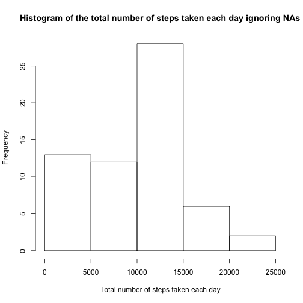

```r
hist(total_steps_by_day_df$total_steps, xlab="Total number of steps taken each day",
     main="Histogram of the total number of steps taken each day ignoring NAs")
```

```r
filtered_am_data <- filter(am_data, steps!=0)
by_day <- group_by(filtered_am_data, date)
mean_median_steps_by_day <- summarise(by_day,
                                      mean_steps=mean(steps, na.rm=TRUE),
                                      median_steps=median(steps, na.rm=TRUE))
mean_median_steps_by_day_df <- data.frame(mean_median_steps_by_day)
mean_median_steps_by_day_df
```

```
##          date mean_steps median_steps
## 1  2012-10-02   63.00000         63.0
## 2  2012-10-03  140.14815         61.0
## 3  2012-10-04  121.16000         56.5
## 4  2012-10-05  154.58140         66.0
## 5  2012-10-06  145.47170         67.0
## 6  2012-10-07  101.99074         52.5
## 7  2012-10-09  134.85263         48.0
## 8  2012-10-10   95.19231         56.5
## 9  2012-10-11  137.38667         35.0
## 10 2012-10-12  156.59459         46.0
## 11 2012-10-13  119.48077         45.5
## 12 2012-10-14  160.61702         60.5
## 13 2012-10-15  131.67532         54.0
## 14 2012-10-16  157.12500         64.0
```

[output cut: 39 more lines]

## What is the average daily activity pattern?

#### Time series plot (i.e. type = “l”) of the 5-minute interval (x-axis) and the average number of steps taken, averaged across all days (y-axis), ignore the missing values in the dataset.

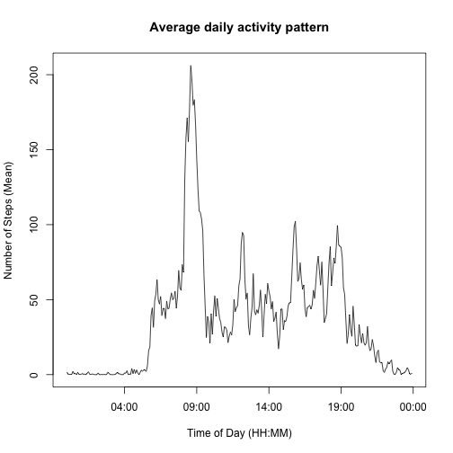

```r
by_interval <- group_by(am_data, interval)
mean_steps_by_interval <- summarise(by_interval,
                                    mean_steps=mean(steps, na.rm=TRUE))
mean_steps_by_interval_df <- data.frame(mean_steps_by_interval)
mean_steps_by_interval_df$simulated_seq <- seq(0, 1435, by=5)
oct1 <- ymd("2012-10-01")
oct2 <- ymd("2012-10-02")
seq_interval <- seq(oct1, oct2, by = "5 min")
mean_steps_by_interval_df$seq_interval <- seq_interval[1:288]
with(mean_steps_by_interval_df, plot(seq_interval, mean_steps, type="l",
                                     xlab="Time of Day (HH:MM)",
                                     ylab="Number of Steps (Mean)",
                                     main="Average daily activity pattern"))
```

#### The 5-minute interval, on average across all the days in the dataset, which contains the maximum number of steps

```r
max_interval <- mean_steps_by_interval_df %>% filter(mean_steps == max(mean_steps))
max_interval
```

```
##   interval mean_steps simulated_seq        seq_interval
## 1      835   206.1698           515 2012-10-01 08:35:00
```

## Imputing missing values

#### Calculate and report the total number of missing values in the dataset (i.e. the total number of rows with NAs)

```r
summary(am_data)
```

```
##      steps            date              interval
##  Min.   :  0.00   Length:17568       Min.   :   0.0
##  1st Qu.:  0.00   Class :character   1st Qu.: 588.8
##  Median :  0.00   Mode  :character   Median :1177.5
##  Mean   : 37.38                      Mean   :1177.5
##  3rd Qu.: 12.00                      3rd Qu.:1766.2
##  Max.   :806.00                      Max.   :2355.0
##  NA's   :2304
```

Total number of rows with NAs is 2304 as seen in the above summary.

#### Create a new dataset that is equal to the original dataset but with the missing data filled in, using the mean for that 5-minute interval.

The strategy is to merge the am_data dataset with the mean_steps_by_interval_df dataset using inner join on the interval key and iterate through the merged dataset replacing missing data with the mean for that 5-minute interval

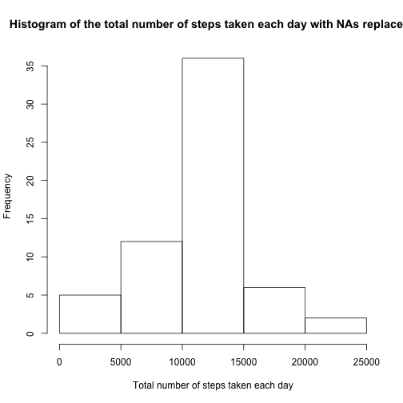

```r
merged_data <- merge(am_data, mean_steps_by_interval_df, by="interval")
replace <- function(steps, mean_steps) {
  if(is.na(steps)) {
    fill <- mean_steps
  } else {
    fill <- steps
  }
  fill
}
filled <- mapply(replace, merged_data$steps, merged_data$mean_steps)
filled_merged_data <- cbind(merged_data, filled)
select_filled_merged_data <- select(filled_merged_data, interval, filled, date)
select_filled_merged_data_by_day <- group_by(select_filled_merged_data, date)
filled_total_steps_by_day <- summarise(select_filled_merged_data_by_day, total_steps=sum(filled, na.rm=TRUE))
filled_total_steps_by_day_df <- data.frame(filled_total_steps_by_day)
hist(filled_total_steps_by_day_df$total_steps, xlab="Total number of steps taken each day",
     main="Histogram of the total number of steps taken each day with NAs replaceed")
```

```r
filtered_filled_merged_data <- filter(filled_merged_data, filled!=0)
filtered_filled_merged_data_by_day <- group_by(filtered_filled_merged_data, date)
filtered_filled_mean_median_steps_by_day <- summarise(filtered_filled_merged_data_by_day,
                                                      mean_steps=mean(filled, na.rm=TRUE),
                                                      median_steps=median(filled, na.rm=TRUE))
filtered_filled_mean_median_steps_by_day_df <- data.frame(filtered_filled_mean_median_steps_by_day)
filtered_filled_mean_median_steps_by_day_df
```

```
##          date mean_steps median_steps
## 1  2012-10-01   40.02301     37.45283
## 2  2012-10-02   63.00000     63.00000
## 3  2012-10-03  140.14815     61.00000
## 4  2012-10-04  121.16000     56.50000
## 5  2012-10-05  154.58140     66.00000
## 6  2012-10-06  145.47170     67.00000
## 7  2012-10-07  101.99074     52.50000
## 8  2012-10-08   40.02301     37.45283
## 9  2012-10-09  134.85263     48.00000
## 10 2012-10-10   95.19231     56.50000
## 11 2012-10-11  137.38667     35.00000
## 12 2012-10-12  156.59459     46.00000
## 13 2012-10-13  119.48077     45.50000
## 14 2012-10-14  160.61702     60.50000
```

[output cut: 47 more lines]

## Are there differences in activity patterns between weekdays and weekends?

#### Create a new factor variable in the dataset with two levels – “weekday” and “weekend” indicating whether a given date is a weekday or weekend day.

```r
select_filled_merged_data$date <- as.Date(select_filled_merged_data$date, "%Y-%m-%d")
isWeekend <- weekdays(select_filled_merged_data$date) %in% c('Saturday', 'Sunday')
weekday.f <- factor(isWeekend, labels=c("weekday", "weekend"))
select_filled_merged_data <- cbind(select_filled_merged_data, isWeekend)
select_filled_merged_data <- cbind(select_filled_merged_data, weekday.f)
```

#### panel plot containing a time series plot (i.e. type = “l”) of the 5-minute interval (x-axis) and the average number of steps taken, averaged across all weekday days or weekend days (y-axis).

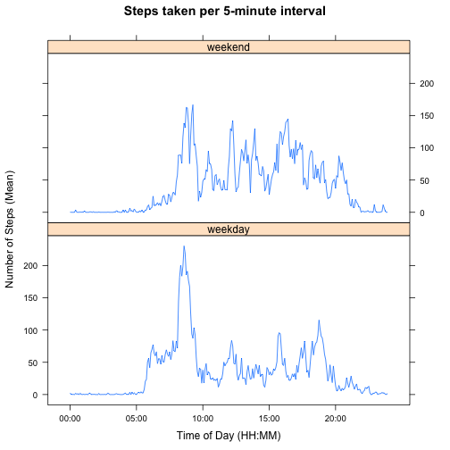

```r
by_weekdayF_interval <- group_by(select_filled_merged_data, weekday.f, interval)
filled_mean_steps_by_interval <- summarise(by_weekdayF_interval,
                                           mean_steps=mean(filled, na.rm=TRUE))
filled_mean_steps_by_interval_df <- data.frame(filled_mean_steps_by_interval)
oct1 <- ymd("2012-10-01")
oct2 <- ymd("2012-10-02")
seq_interval <- seq(oct1, oct2, by = "5 min")
weekday <- seq_interval[1:288]
weekend <- seq_interval[1:288]
seq_interval <- combine(weekday, weekend)
filled_mean_steps_by_interval_df <- cbind(filled_mean_steps_by_interval_df, seq_interval)
library(lattice)
time_series <- seq(oct1, oct2, by="5 hours")
xyplot(mean_steps ~ seq_interval | weekday.f, data = filled_mean_steps_by_interval_df, layout = c(1, 2), type = "l",
       scales=list(x=list(at=time_series, labels=format(time_series, "%H:%M"))),
       xlab="Time of Day (HH:MM)",
       ylab="Number of Steps (Mean)",
       main="Steps taken per 5-minute interval")
```